# EDA Prosper Loan Data Analyzed by Costa Stamatinos

The dataset I am going to explore is the Prosper Loan Data provided for the course. The data has 113937 observations(loans), with 81 variables(loan number, rate, etc). While most of the data is numerical, 15 variables out of the 81 are vectors(non‐numerical). The most interesting variables at the start are concerned with the amount of money loaned, and the rates for repaying it. A sample was created for this analysis of 10000 random loans.

#### Summary of the Sample

The factored data is discrete and is plotted using bar plots and columns. The numerical data can be analyzed further with built in functions and histograms. I started by looking through the data and looking at some summaries. After exploring, I found that some of the variables were components of others. The [variable definitions](https://www.google.com/url?q=https://docs.google.com/spreadsheets/d/1gDyi_L4UvIrLTEC6Wri5nbaMmkGmLQBk-Yx3z0XDEtI/edit?usp%3Dsharing&sa=D&ust=1515110277680000&usg=AFQjCNFhw421fbcJIWcL7z8kFO8b_Vz2cQ) were handy in picking what I wanted to look at. I wanted to further explore the rates and amounts of the loans as well as the loss or gain of the lender. Here are the variables chosen and a summary of each.

```
##  [1] "LoanNumber"              "LoanOriginationDate"
##  [3] "LoanOriginalAmount"      "StatedMonthlyIncome"
##  [5] "MonthlyLoanPayment"      "BorrowerAPR"
##  [7] "CreditGrade"             "Term"
##  [9] "EstimatedLoss"           "EstimatedReturn"
## [11] "ProsperRating..numeric." "BorrowerState"
## [13] "CreditScoreRangeLower"   "Occupation"
## [15] "IncomeRange"
```

```
##    LoanNumber     LoanOriginationDate  LoanOriginalAmount
##  Min.   :    23   Min.   :2006-01-10   Min.   : 1000
##  1st Qu.: 36924   1st Qu.:2008-09-23   1st Qu.: 4000
##  Median : 68545   Median :2012-06-25   Median : 6500
##  Mean   : 69284   Mean   :2011-07-15   Mean   : 8350
##  3rd Qu.:101767   3rd Qu.:2013-09-18   3rd Qu.:12000
##  Max.   :136486   Max.   :2014-03-12   Max.   :35000
##
##  StatedMonthlyIncome MonthlyLoanPayment  BorrowerAPR      CreditGrade
##  Min.   :      0     Min.   :   0.0     Min.   :0.0165   C      : 494
##  1st Qu.:   3242     1st Qu.: 132.7     1st Qu.:0.1546   D      : 461
##  Median :   4617     Median : 218.3     Median :0.2081   B      : 381
##  Mean   :   5779     Mean   : 272.9     Mean   :0.2181   AA     : 323
##  3rd Qu.:   6717     3rd Qu.: 373.3     3rd Qu.:0.2819   HR     : 303
##  Max.   :1750003     Max.   :2218.5     Max.   :0.4135   (Other): 615
##                                         NA's   :1        NA's   :7423
##       Term       EstimatedLoss    EstimatedReturn
##  Min.   :12.00   Min.   :0.0060   Min.   :-0.0648
##  1st Qu.:36.00   1st Qu.:0.0424   1st Qu.: 0.0746
##  Median :36.00   Median :0.0699   Median : 0.0911
##  Mean   :40.88   Mean   :0.0799   Mean   : 0.0960
##  3rd Qu.:36.00   3rd Qu.:0.1120   3rd Qu.: 0.1160
##  Max.   :60.00   Max.   :0.3660   Max.   : 0.2538
##                  NA's   :2589     NA's   :2589
##  ProsperRating..numeric. BorrowerState  CreditScoreRangeLower
##  Min.   :1.000           CA     :1309   Min.   :  0.0
##  1st Qu.:3.000           TX     : 629   1st Qu.:660.0
##  Median :4.000           FL     : 608   Median :680.0
##  Mean   :4.086           NY     : 562   Mean   :685.2
##  3rd Qu.:5.000           IL     : 530   3rd Qu.:720.0
##  Max.   :7.000           (Other):5863   Max.   :880.0
##  NA's   :2589            NA's   : 499   NA's   :59
##                Occupation           IncomeRange
##  Other              :2460   $25,000-49,999:2838
##  Professional       :1251   $50,000-74,999:2725
##  Computer Programmer: 408   $100,000+     :1521
##  Executive          : 365   $75,000-99,999:1464
##  Teacher            : 338   Not displayed : 701
##  (Other)            :4873   $1-24,999     : 617
##  NA's               : 305   (Other)       : 134
```

A few things of note from looking at the summaries. Credit grade has the highest number of missing data points(NA). Estimated loss, estimated return and prosper score each have over a quarter missing. The loan data starts in 2006 through 2014, but most were after 2009. The max amount loaned was $35000. We can infer from that that these were not mortgage loans. Lastly of interest is the maximum stated income of $1,750,003 a month! This is most likely a mistake or an outlier.

## Univariate Plots Section

Single variable plots of vectors. I started with the non‐numerical data. Any observations are at the end of the section.

#### Non‐Numerical Data

Credit grade variable definition: The Credit rating that was assigned at the time the listing went live. Applicable for listings pre‐2009 period and will only be populated for those listings.

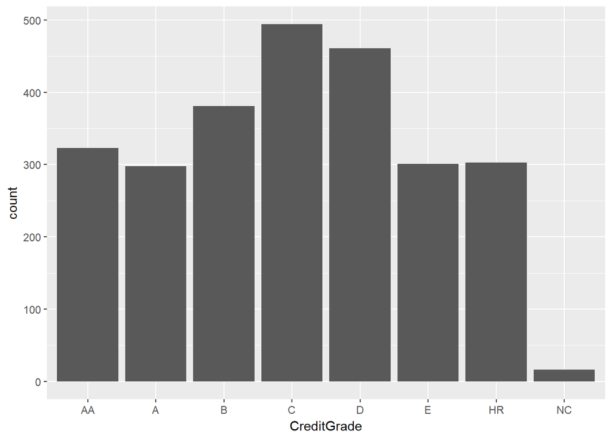

Borrower state variable definition: The two letter abbreviation of the state of the address of the borrower at the time the Listing was created.

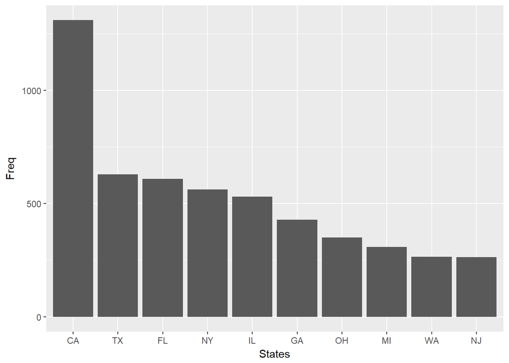

Occupation variable definition: The Occupation selected by the Borrower at the time they created the listing.

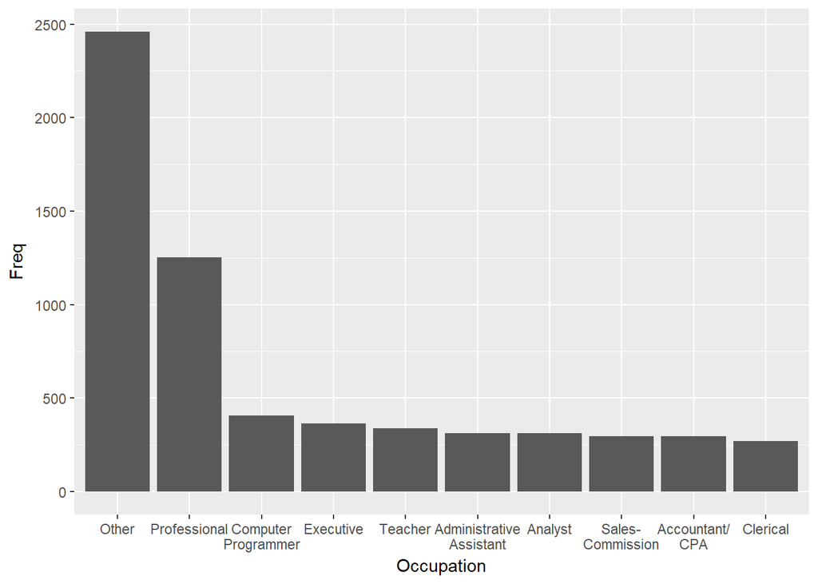

Income range variable definition: The income range of the borrower at the time the listing was created.

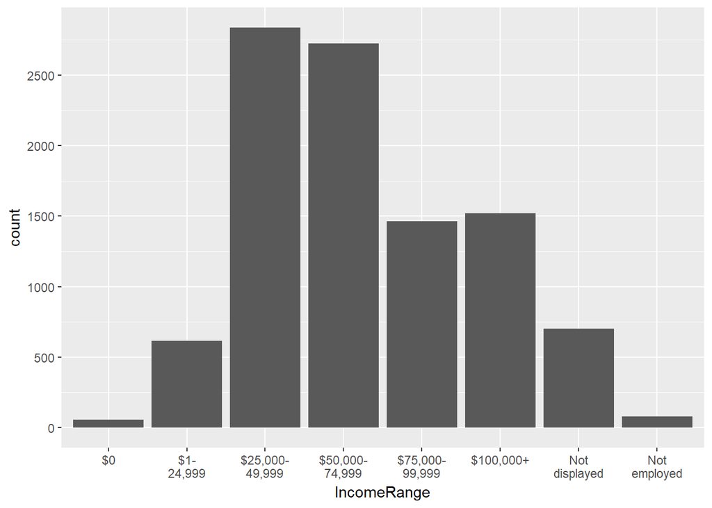

Term is presented here as a numerical variable, but given that it is only three options I put it with the factored data.

Term variable definition: The length of the loan expressed in months.

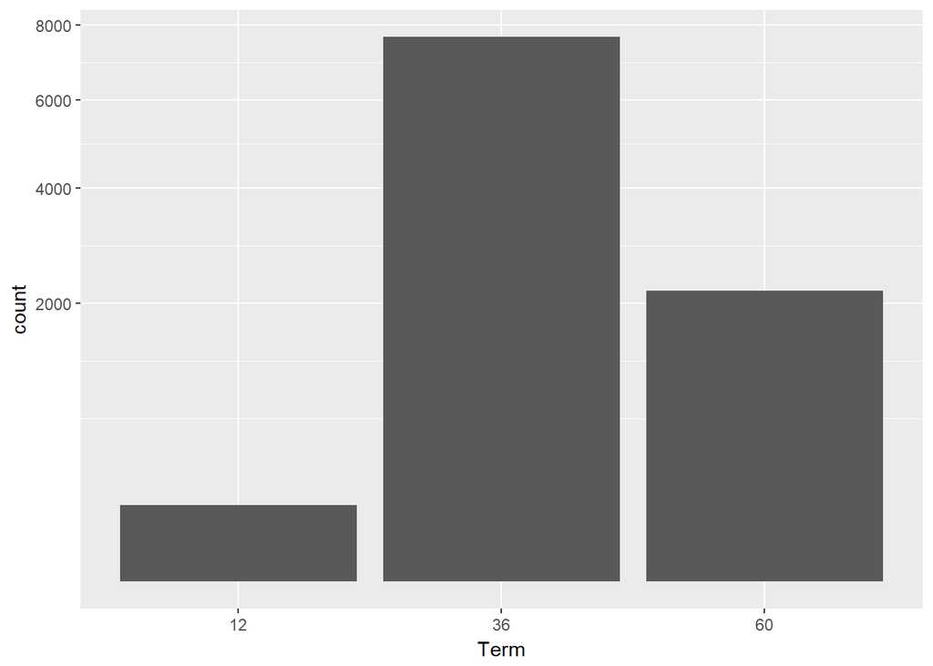

Looking at term we can see that indeed these are smaller loans for shorter amounts of time. We can also see that larger states contribute more, but California is the top with more than double its closest state, Texas. The occupations counted professional as the largest named group. The income range shows an almost normal distribution skewed right with a high number in the $100,000+ range. Over half of loaners are in the $25,000 to $75,000 range, while a third are in the $75,000+ range.

#### Numerical Data

Single variable plots of numerical data. The numerical data makes up most of this data set. Any observations are at the end of the section.

Loan origination date variable definition: The date the loan was originated.

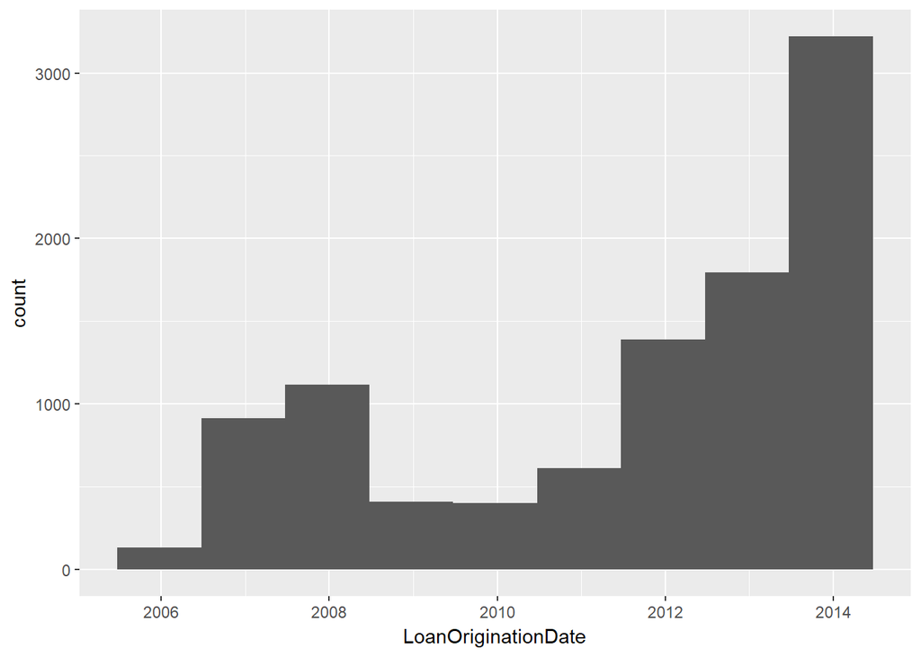

```
##         Min.      1st Qu.       Median         Mean      3rd Qu.
## "2006-01-10" "2008-09-23" "2012-06-25" "2011-07-15" "2013-09-18"
##         Max.
## "2014-03-12"
```

Loan original amount variable definition: The origination amount of the loan.

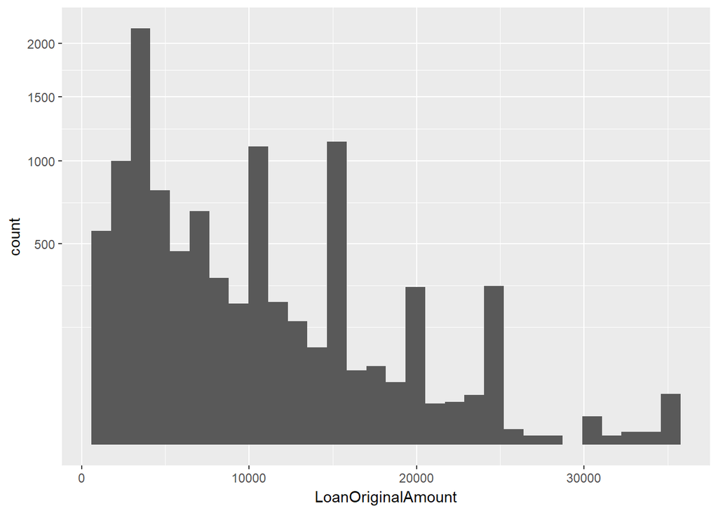

```
##    Min. 1st Qu.  Median    Mean 3rd Qu.    Max.
##    1000    4000    6500    8350   12000   35000
```

Stated monthly income variable definition: The monthly income the borrower stated at the time the listing was created.

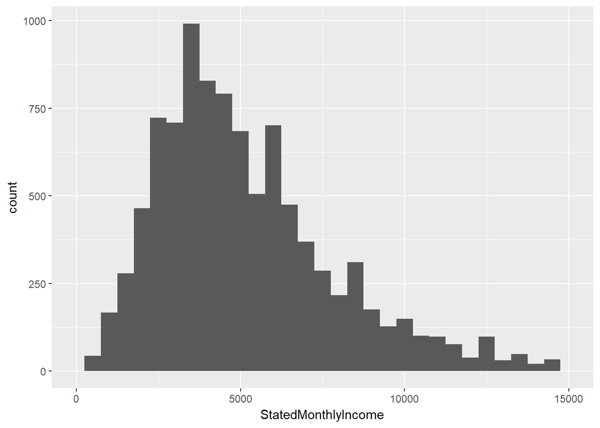

```
##    Min. 1st Qu.  Median    Mean 3rd Qu.    Max.
##       0    3242    4617    5779    6717 1750003
```

Monthly loan payment variable definition: The scheduled monthly loan payment.

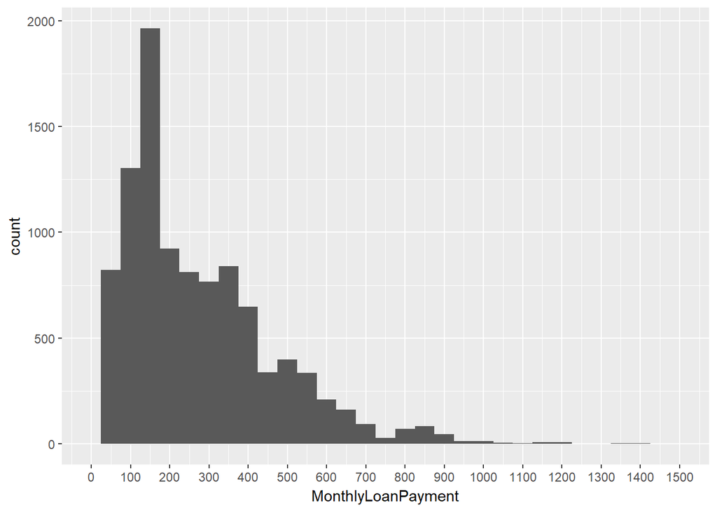

```
##    Min. 1st Qu.  Median    Mean 3rd Qu.    Max.
##     0.0   132.7   218.3   272.9   373.3  2218.5
```

Borrower APR variable definition: The Borrower’s Annual Percentage Rate (APR) for the loan.

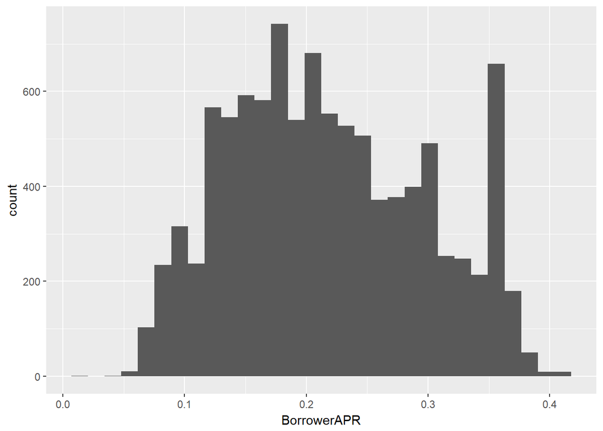

```
##    Min. 1st Qu.  Median    Mean 3rd Qu.    Max.    NA's
##  0.0165  0.1546  0.2081  0.2181  0.2819  0.4135       1
```

Esitimated loss variable definition: Estimated loss is the estimated principal loss on charge‐offs. Applicable for loans originated after July 2009.

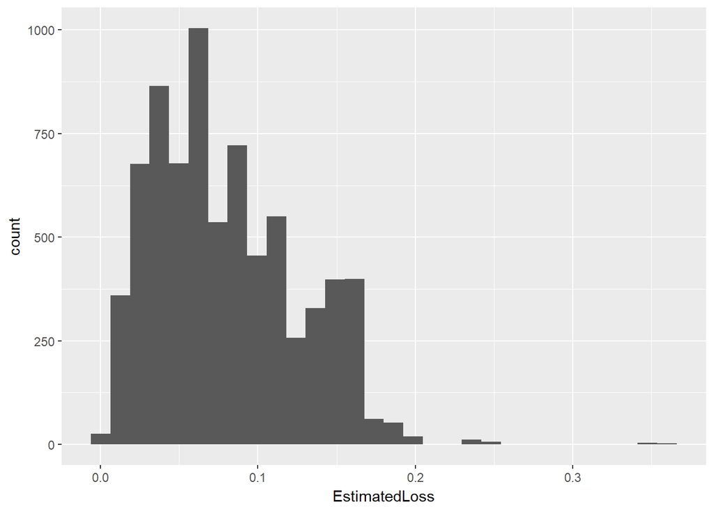

```
##    Min. 1st Qu.  Median    Mean 3rd Qu.    Max.    NA's
##  0.0060  0.0424  0.0699  0.0799  0.1120  0.3660    2589
```

Estimated return variable definition: The estimated return assigned to the listing at the time it was created. Estimated return is the difference between the Estimated Effective Yield and the Estimated Loss Rate. Applicable for loans originated after July 2009.

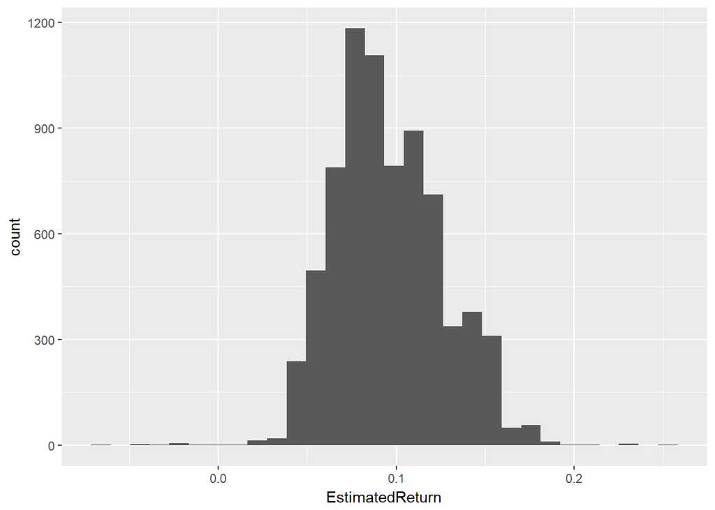

```
##    Min. 1st Qu.  Median    Mean 3rd Qu.    Max.    NA's
## -0.0648  0.0746  0.0911  0.0960  0.1160  0.2538    2589
```

Prosper rating numeric variable definition:The Prosper Rating assigned at the time the listing was created: 0 ‐ N/A, 1 ‐ HR, 2 ‐ E, 3 ‐ D, 4 ‐ C, 5 ‐ B, 6 ‐ A, 7 ‐ AA. Applicable for loans originated after July 2009.

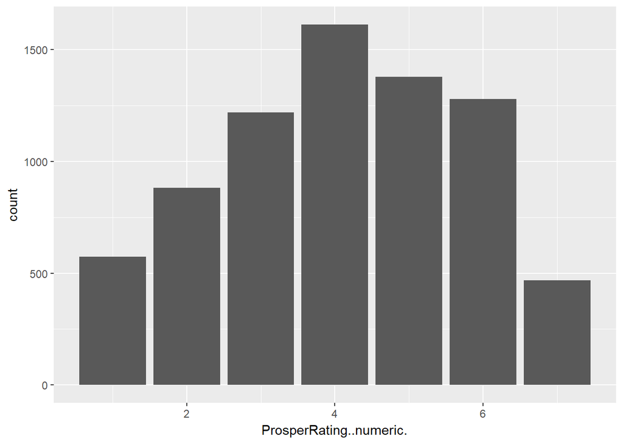

```
##    Min. 1st Qu.  Median    Mean 3rd Qu.    Max.    NA's
##   1.000   3.000   4.000   4.086   5.000   7.000    2589
```

Credit score range lower variable definition: The lower value representing the range of the borrower’s credit score as provided by a consumer credit rating agency.

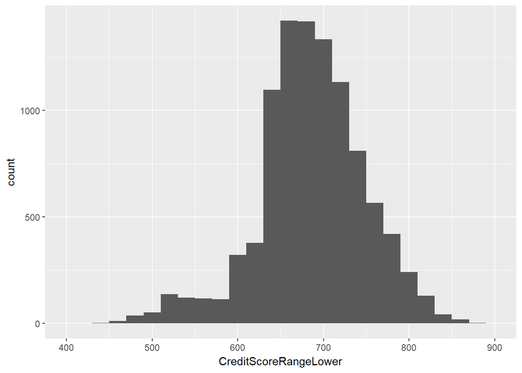

```
##    Min. 1st Qu.  Median    Mean 3rd Qu.    Max.    NA's
##     0.0   660.0   680.0   685.2   720.0   880.0      59
```

#### Duplicates and Exploring Loaners

I noticed duplicate member keys and created a data frame of just the repeat loaners and arranged it by member key and date. I also added a IsLoaner logic variable to the sample data frame. The effects of having multiple loans with Prosper can now be explored two ways. Using the data frame to look at the details and using the variable to see general trends.

Checking for duplicates in member keys. Member keys variable definition: The unique key that is associated with the borrower. Table of the top six borowers id number and count of loans.

```
##
## 5AD03382187155131B956C2 1F7C3375606515043599438 41893364980917373A233F4
##                       4                       3                       3
## 5C51337031034709696F2C3 699B3417232917446D6E2F9 69A43405319925169FEF5AF
##                       3                       3                       3
```

Creating a loners data frame and adding the IsLoaner to the sample.

```r
#Create a data frame subset of only people with multiple loans
templist <- subset(data.frame(sort(table(samp_ldf$MemberKey), decreasing = T)),
                  Freq > 1)
loaners <- subset(samp_ldf, MemberKey %in% templist[[1]])
loaners <- arrange(loaners, loaners$MemberKey, loaners$LoanOriginationDate)

#Create a logical variable in the sample for serial loaners,  True/False
samp_ldf$IsLoaner <- samp_ldf$MemberKey %in% loaners$MemberKey
```

The average change in Prosper rating for people who borrowed multiple times.

```
## [1] 0.7123288
```

It seems that on average lenders Prosper score increased the more loans they had with Prosper. More exploration was performed and no other interesting data from these variables was found.

# Univariate Analysis

That is one large data set! Out of the 81 variables many were related to each other. I concentrated on a few variables, but more could be done with a program like Tableau. It would make it easier to compare all there is.

### What is/are the main feature(s) of interest in your dataset?

Since the data set is concerned with money, the obvious interest lies in who’s getting how much. Borrowers are interested in how much they can get and their monthly payment. Lenders are interested in how much they will get in terms of yield, return, and loss.

### What other features in the dataset do you think will help support your investigation into your feature(s) of interest?

Some variables are constructed using other variables, so natural correlation will be easily visible in those. I choose ones that stand out the best visually to compare with others. Again, dealing with money, numerical variables will be the place to start, but it will be interesting to see how factored variables effect the money.

### Did you create any new variables from existing variables in the dataset?

Yes, several to explore duplicates in member keys, and several to help plot interesting data.

### Of the features you investigated, were there any unusual distributions? Did you perform any operations on the data to tidy, adjust, or change the form of the data? If so, why did you do this?

Most of the distributions were close to normal. Some had slight plateaus, and many were skewed. I did have to organize and trim some of the data to fit nicely into graphs, or to see changes over time for the loaners data.

# Bivariate Plots Section

I created a correlation matrix of a few variables to start the exploration of multiple variables. It yielded a few interesting observations. The red highlighted values are the highly correlated variables while the green is less, but still interesting.

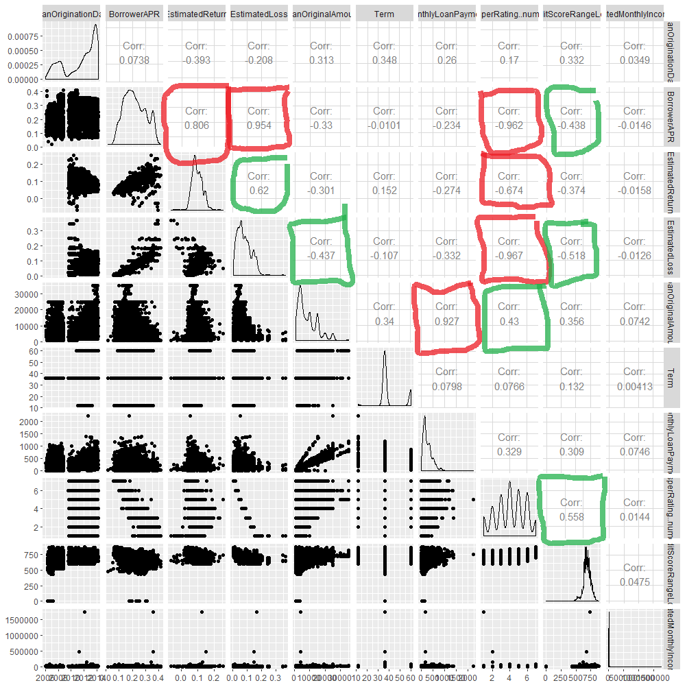

It is easy to see that both borrower APR and prosper rating both have 3 highly correlated scores. These are the areas that I focused on.

Point plots of borrower APR and date.

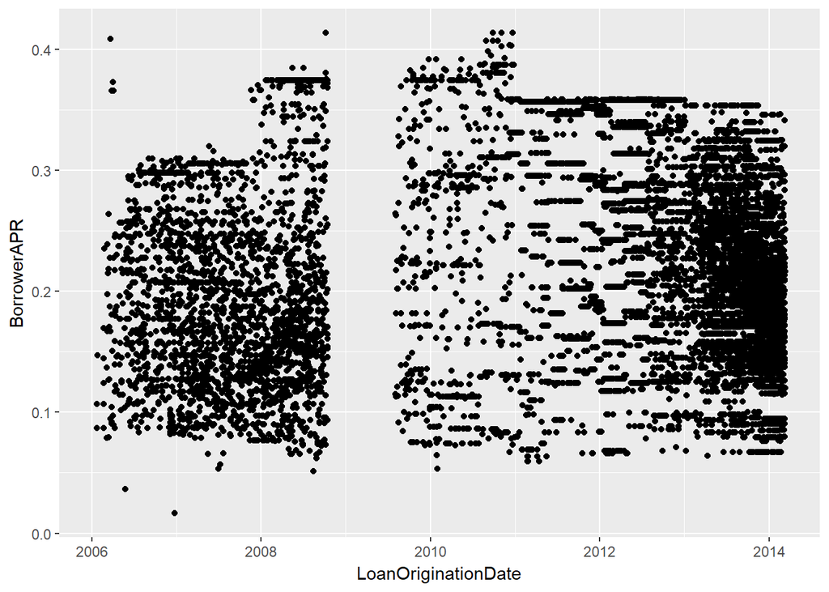

Point plots of estimated loss and return.

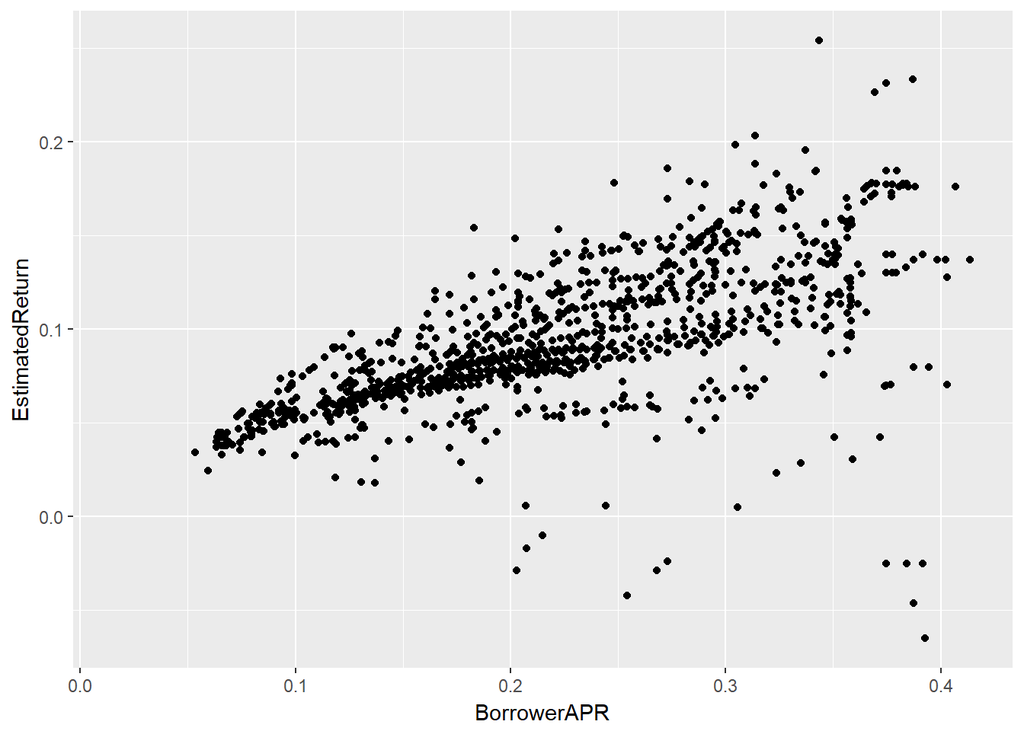

```
## Correlation: 0.8057518
```

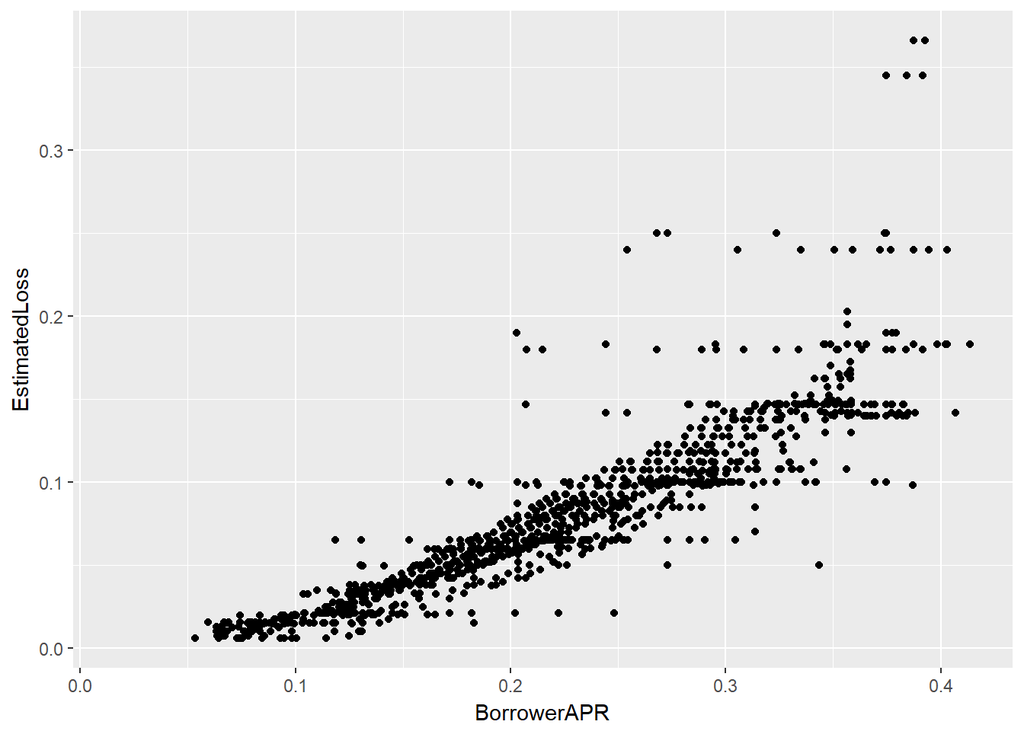

```
## Correlation: 0.9543014
```

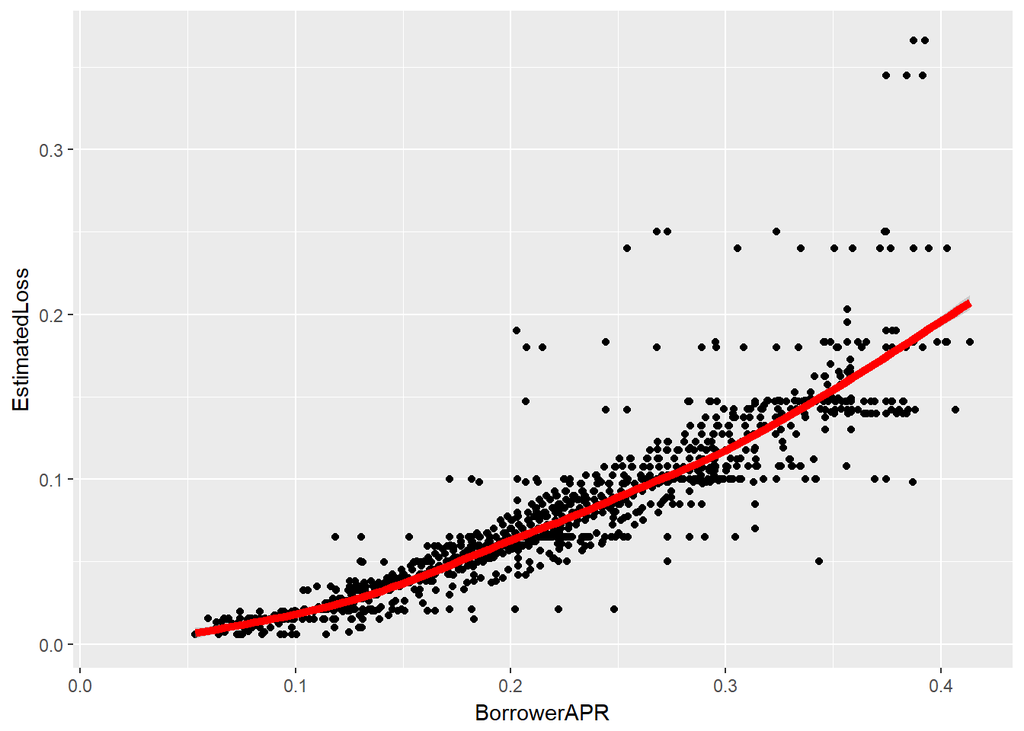

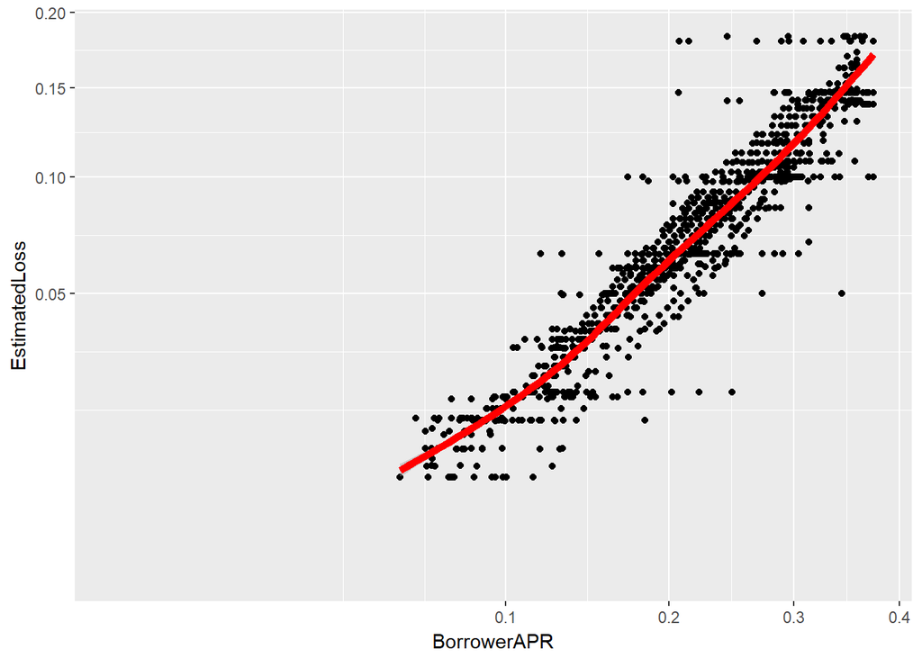

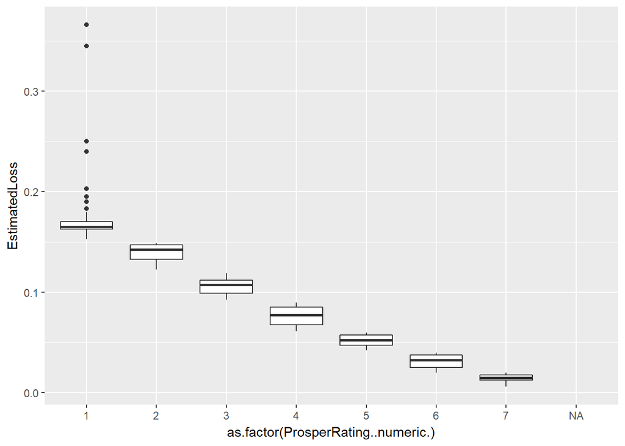

```
## Correlation: -0.9671393
```

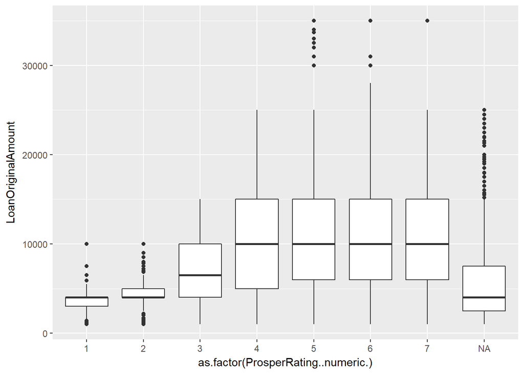

```
## Correlation: 0.4302681
```

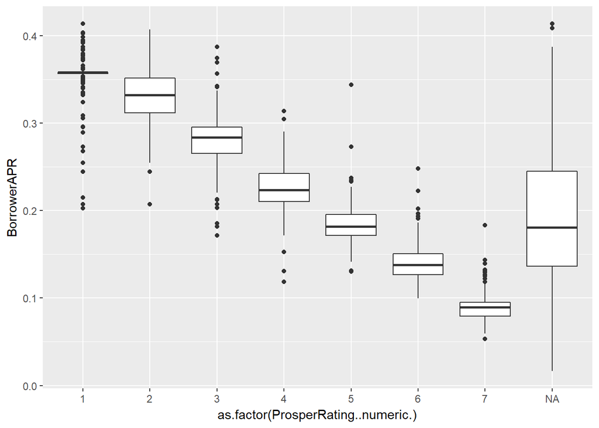

```
## Correlation: -0.9623069
```

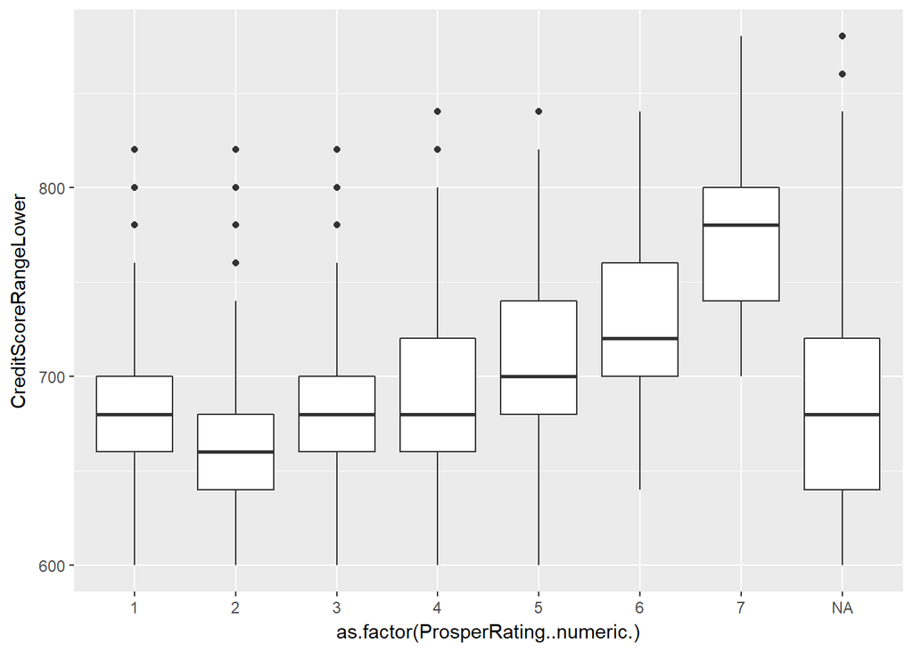

```
## Correlation: 0.5576186
```

Here you can see the steady drop in estimated loss with the rise in Prosper rating, with newly rated at 1 being the most volatile. This coincides with loan amounts. Different max loan amounts apply to different ratings. No loans above $20,000 for anyone under a rating of 4. Lastly APR also decreases with a rise in Prosper rating. So, both APR and loss drop as the rating increases, coincidental?

Point plots of loan amount vs monthly payment.

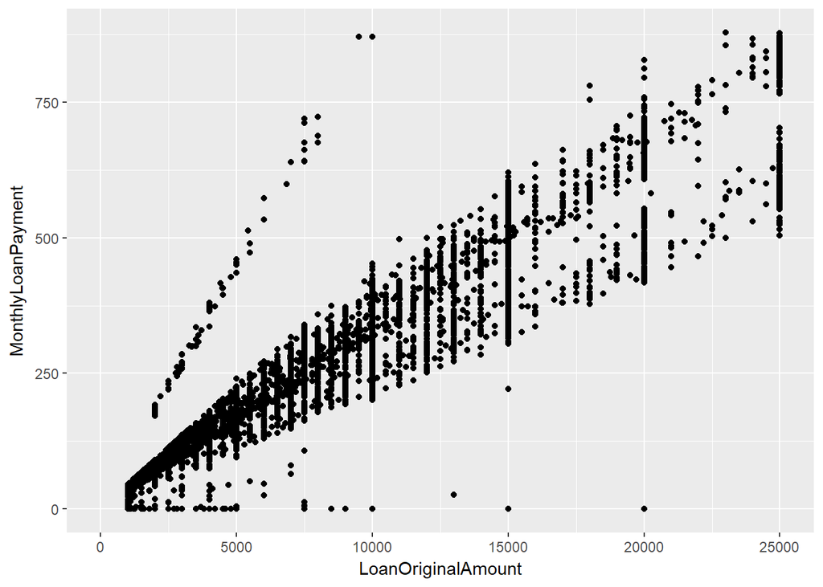

```
## Correlation: 0.9274069
```

Here is another set of highly correlated variables. Its apparent that monthly payments go up as the original amount goes up, but it seems to have three distinct vectors.

# Bivariate Analysis

### Talk about some of the relationships you observed in this part of the investigation. How did the feature(s) of interest vary with other features in the dataset?

The relationships I explored were all highly linked. I choose my variables based on what was of interest to most people. Natural relationships like monthly payments and original amount are present along with some surprises.

### Did you observe any interesting relationships between the other features (not the main feature(s) of interest)?

I purposefully picked my variables because of the size of the data set. I did do some preliminary exploration of the others, the relationship of lender yield and borrower rate had the highest correlation. It was .999. I will plot it in the multivariable section.

# Multivariate Plots Section

Plots of APR and rate against loss and yield with Prosper rating as the color.

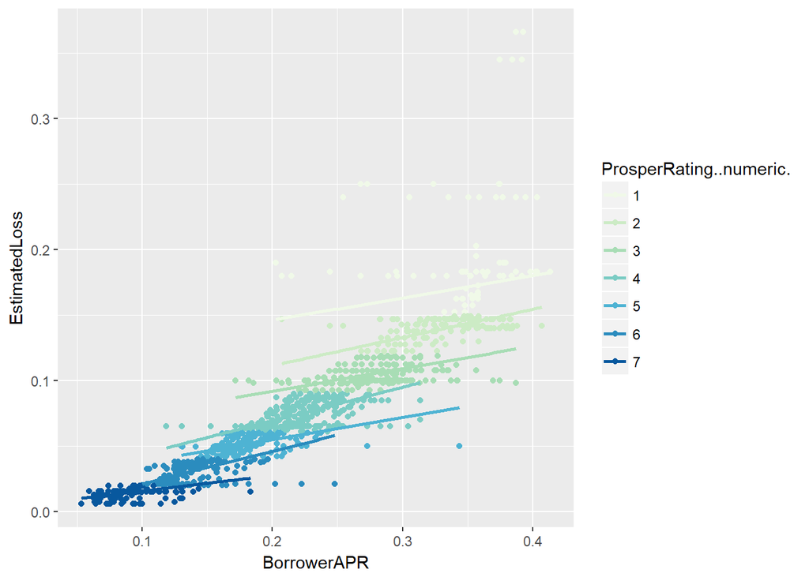

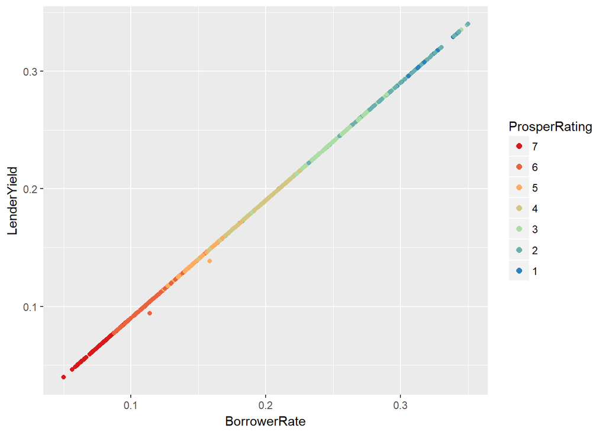

Wow! That is a strongly correlated set of variables! As you can see the Prosper rating change is very apparent when we add color to the plots. As the two main variables increase, Prosper rating decreases steadily.

Plot of APR against loss with loan date as the color.

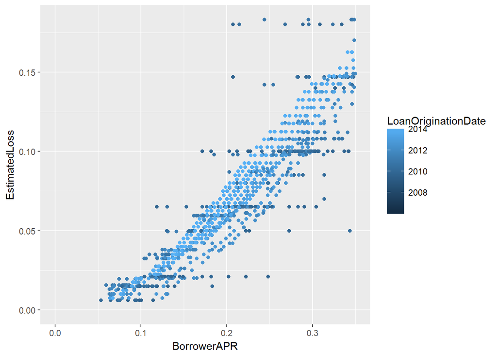

Here you can see that older loans had an interval between estimated loss and borrower rate. After 2009, a different scale was used to calculate these numbers. The older dates look mostly horizontal while the newer dates appear to be on a nearly linear scale.

Plots of monthy payments against loan amount with several color variables.

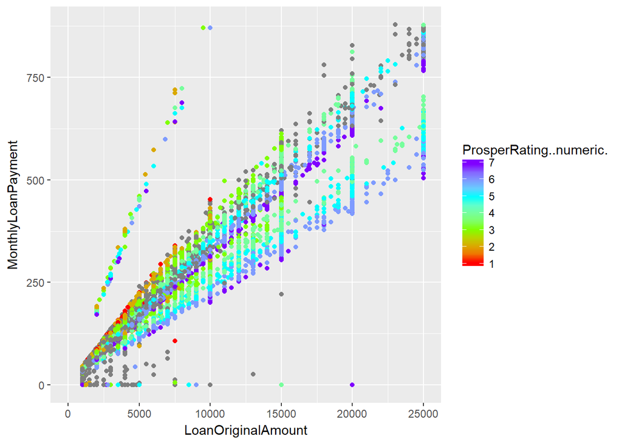

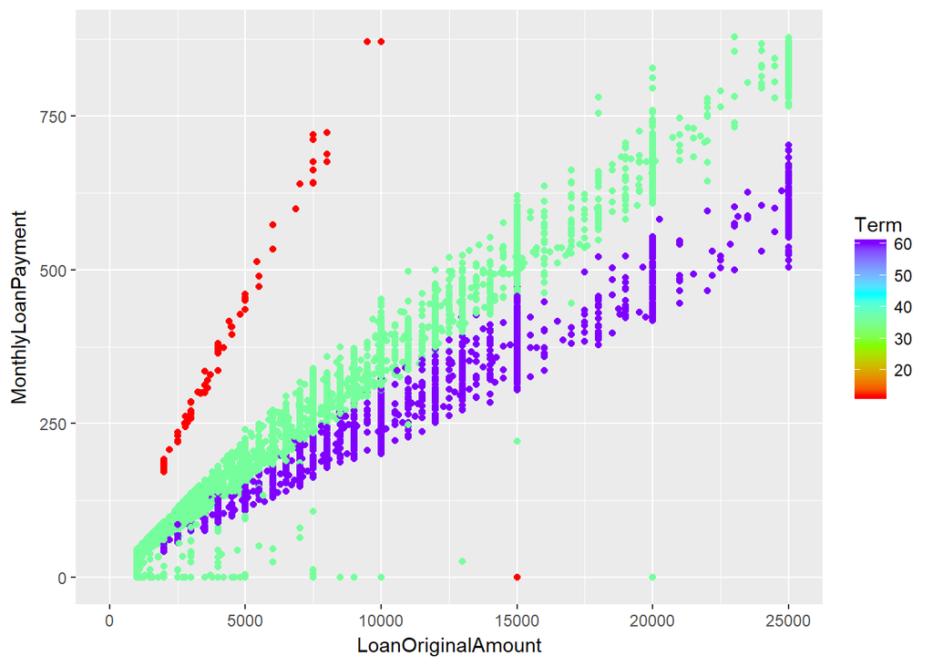

Prosper rating again shows an interesting pattern with higher ratings receiving the lowest monthly payments across the board. Not surprising considering better ratings mean better APR. The next plot shows the real breakdown of these two variables. With term as the color, each vector now makes sense. Each is grouped by term. Also showing that for each term, higher Prosper rating means lower payments.

Plot of Prosper rating against credit score with APR as the color.

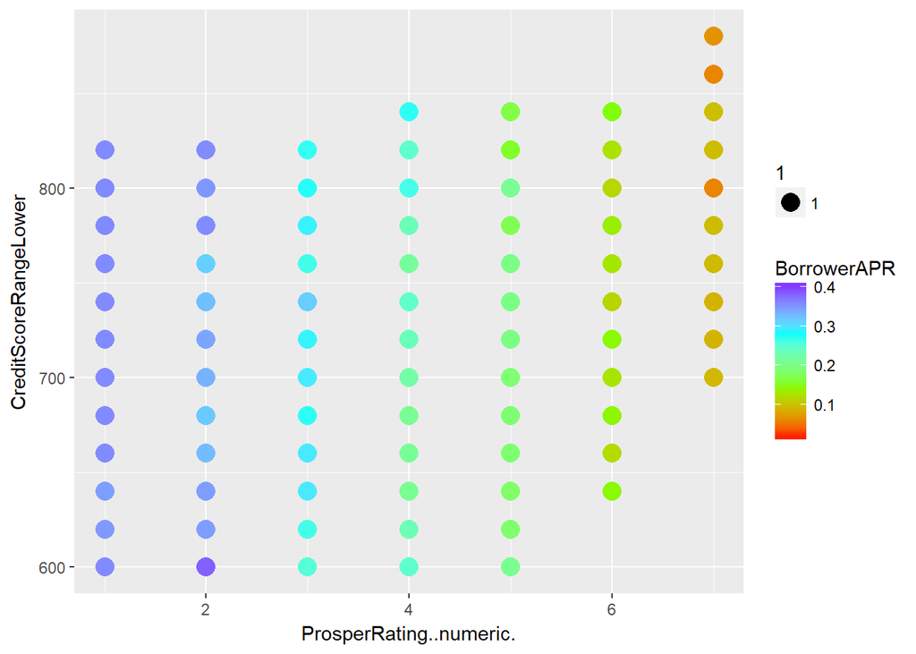

Lastly credit score is shown to have less of an effect on APR than Prosper rating. Here credit scores are evenly distributed, but APR decreases as rating increases.

# Multivariate Analysis

### Talk about some of the relationships you observed in this part of the investigation. Were there features that strengthened each other in terms of looking at your feature(s) of interest?

Looking at the data with a third variable as color made an instant impact. Trends and surprises were both shown very easily. Dates helped show changes in how the banks calculate their profits. Prosper rating was the best variable for color showing up in half of my multivariable plots.

### Were there any interesting or surprising interactions between features?

The effect that Prosper rating had on many of the variables was surprising. It played a larger role than I originally thought.

### OPTIONAL: Did you create any models with your dataset? Discuss the strengths and limitations of your model.

No, the data set was very large, so I decided not to pursue modeling it.

# Final Plots and Summary

### Plot One

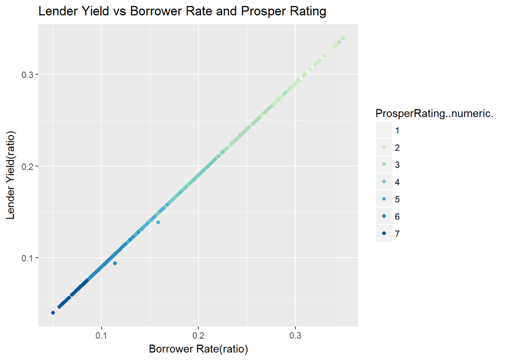

### Description One

This is the data sets most correlated values. It also shows the separation and effect of Prosper ratings on borrower rate and lender yield. I chose this as a breakdown of most of what I found. It has important variables for all concerned, as well as a good visualization.

### Plot Two

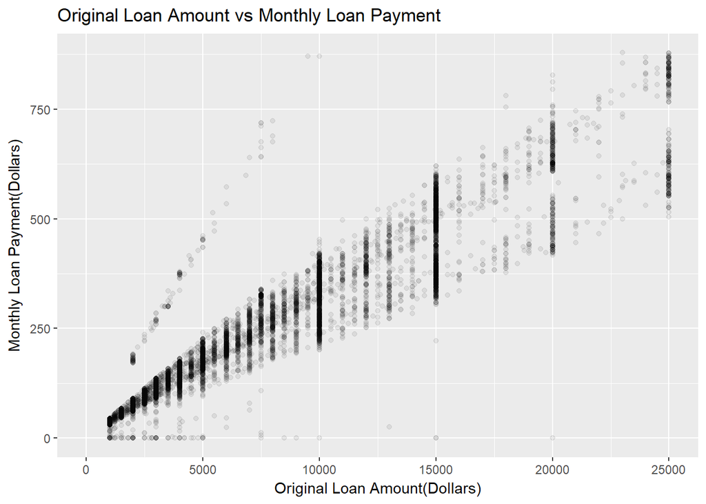

### Description Two

This plot shows that just looking at two variables is not always enough to get a good grasp of the data. I spent a long time trying to figure out what made the three distinct vectors in this plot. The obvious separation was something that I wanted to explain. I chose this plot because of the challenge of finding that explanation.

### Plot Three

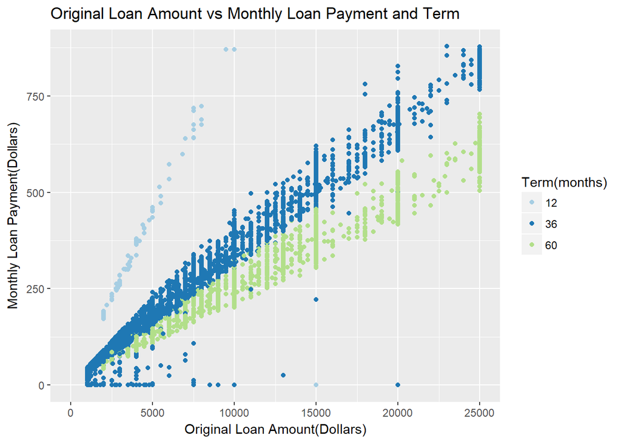

### Description Three

I found it! It was many plots and frustrated hours trying to find the right third variable to paint this picture. Finally, term was used, and it was immediately clear. Each vector in the plot was based off a group of loans for that term. And each term had a different payment/total amount ratio. Of course, this makes sense, shorter terms have smaller amounts, but higher monthly payments.

# Reflection

Reflecting on this project, I found it very difficult. The size of the data set along with the direct manipulation of code in R made it hard. A smaller set, or an easier program might have made it better. I found that credit scores and monthly income are not the guaranteed of a good rate I thought they were. Seems that ratings with your bank, and estimated loss have a much stronger pull. I struggled with the size of the data, and with a few HTML bumps. Stopping and coming back to it helped a lot. Lots of surprises were strewn throughout. One of the biggest was the almost perfect correlation between lender yield and borrower rate, .999. Much more could be done with this data set, including considering occupation and employment duration a little more. The best thing to do would be use a program like Tableau to look at the data faster. I understand learning R and I am glad I did, but Tableau or other programs like it just increase the productivity on data sets like this one.